# Определение стоимости автомобилей

# Описание проекта

Сервис по продаже автомобилей с пробегом «Не бит, не крашен» разрабатывает приложение для привлечения новых клиентов. В нём можно быстро узнать рыночную стоимость своего автомобиля. В вашем распоряжении исторические данные: технические характеристики, комплектации и цены автомобилей. Вам нужно построить модель для определения стоимости.

Заказчику важны:

- качество предсказания;
- скорость предсказания;
- время обучения.

# Цель проекта

Решение задачи регрессии и обучения с учителем.

Построить модель машинного обучения для расчета пользователями приложения рыночной стоимости их автомобиля./

# Инструкция по выполнению проекта

Чтобы усилить исследование, не ограничивайтесь градиентным бустингом. Попробуйте более простые модели — иногда они работают лучше. Эти редкие случаи легко пропустить, если всегда применять только бустинг.

Поэкспериментируйте и сравните характеристики моделей: время обучения, время предсказания, точность результата.

**Основные шаги:**

1. Загрузите данные.
2. Изучите данные. Заполните пропущенные значения и обработайте аномалии в столбцах. Если среди признаков имеются неинформативные, удалите их.
3. Подготовьте выборки для обучения моделей.
4. Обучите разные модели, одна из которых — LightGBM, как минимум одна — не бустинг. Для каждой модели попробуйте разные гиперпараметры.
5. Проанализируйте время обучения, время предсказания и качество моделей.
6. Опираясь на критерии заказчика, выберете лучшую модель, проверьте её качество на тестовой выборке.

**Примечания:**

- Для оценки качества моделей применяйте метрику RMSE.
- Значение метрики RMSE должно быть меньше 2500.
- Самостоятельно освойте библиотеку LightGBM и её средствами постройте модели градиентного бустинга.
- Время выполнения ячейки кода Jupyter Notebook можно получить специальной командой. Найдите её.
- Модель градиентного бустинга может долго обучаться, поэтому измените у неё только два-три параметра.
- Если перестанет работать Jupyter Notebook, удалите лишние переменные оператором del.

# Описание данных

Данные находятся в файле `/datasets/autos.csv`.

**Признаки**

- `'DateCrawled'` — дата скачивания анкеты из базы
- `'VehicleType'` — тип автомобильного кузова
- `'RegistrationYear'` — год регистрации автомобиля
- `'Gearbox'` — тип коробки передач
- `'Power'` — мощность (л. с.)
- `'Model'` — модель автомобиля
- `'Kilometer'` — пробег (км)
- `'RegistrationMonth'` — месяц регистрации автомобиля
- `'FuelType'` — тип топлива
- `'Brand'` — марка автомобиля
- `'Repaired'` — была машина в ремонте или нет
- `'DateCreated'` — дата создания анкеты
- `'NumberOfPictures'` — количество фотографий автомобиля
- `'PostalCode'` — почтовый индекс владельца анкеты (пользователя)
- `'LastSeen'` — дата последней активности пользователя

**Целевой признак**

- `'Price — цена (евро)

## Подготовка данных

### Импорт библиотек

```python
# Обновление библиотеки sklearn
!pip install --upgrade scikit-learn -q
```

```python
import re
import time

import pandas as pd
import numpy as np
import matplotlib.pyplot as plt
import seaborn as sns
import lightgbm as lgb

from sklearn.preprocessing import (
    LabelEncoder,
    OneHotEncoder,
    StandardScaler
)

from IPython.display import HTML
from sklearn.model_selection import train_test_split
from sklearn.compose import ColumnTransformer
from sklearn.pipeline import Pipeline
from sklearn.metrics import mean_squared_error
from sklearn.linear_model import LinearRegression
from sklearn.ensemble import RandomForestRegressor
from catboost import CatBoostRegressor
```

```python
!pip install phik -q
import phik
```

```python
RANDOM_STATE = 12345
```

### Создание функций

Создадим функции, которые нам потребуются в работе.

```python
# Функция для отображения списка только
# категориальных столбцов датафрейма.
def cat_col(data):
    return data.select_dtypes(exclude=['number', 'datetime64']).columns
```

```python
# Функция для отображения списка только
# количественных столбцов датафрейма.
def num_col(data):
    return data.select_dtypes(include=['number', 'datetime64']).columns
```

```python
# Функция для предварительного изучения
# общей информации о данных.
def data_research(dataset):

    display(dataset.head())
    display(dataset.tail())
    print()


    display(HTML('<h3>Общая информация о данных</h3><br>'))
    print(dataset.info())


    display(HTML('<h3>Наименования столбцов</h3><br>'))
    print(dataset.columns)


    display(HTML('<br><h3>Количество и доля пропущенных значений</h3><br>'))

    if dataset.isna().sum().any():

        display(HTML(
            f'<b>Количество пропусков во всем датафрейме: </b>'\
            f'{dataset.isna().sum().sum()} '\
            f'({round((dataset.isna().sum().sum() / (dataset.shape[0] * dataset.shape[1]) * 100), 1)}%)<br>')
            )

        display(HTML(
            f'<b>Записи, имеющие хотя бы один пропуск: </b>'\
            f'{dataset[dataset.columns].isna().any(axis=1).sum()} '\
            f'({round((dataset[dataset.columns].isna().any(axis=1).sum() / dataset.shape[0] * 100), 1)}%)<br>')
            )

        display(HTML('<b>Количество пропусков в каждом столбце: </b>'))
        display(pd.DataFrame({
            'count': dataset.isna().sum(),
            '%': dataset.isna().mean() * 100
            }).style.set_precision(1).background_gradient('coolwarm'))

    else:
        print('Пропуски отсутствуют')


    display(HTML('<br><h3>Количество дубликатов в датафрейме</h3><br>'))

    print(f'Всего: {dataset.duplicated().sum()} '
          f'({(dataset.duplicated().sum() / dataset.shape[0]):.2%} '\
          f'от общего размера)')



    display(HTML('<br><h3>Уникальные значения в датафрейме</h3><br>'))

    for column in dataset.columns:
        display(HTML(f'<b>Уникальные значения в столбце "{column}": </b>'\
                     f'{len(dataset[column].unique())}'))

        print(dataset.sort_values(by=column)[column].unique())



    if len(num_col(dataset)) != 0:

        display(HTML('<br><h3>Описание данных</h3>'))
        display(dataset.describe())

        display(HTML('<br><h3>Гистограммы для всех числовых столбцов</h3><br>'))
        num_plots = len(num_col(dataset))
        num_rows = (num_plots + 1) // 2

        # Создание фигуры и осей
        fig, axes = plt.subplots(num_rows, 2, figsize=(14, 5 * num_rows))

        # Построение гистограмм
        for i, column in enumerate(num_col(dataset)):
            row = i // 2
            col = i % 2
            sns.histplot(data=dataset, x=column, bins=20, ax=axes[row, col])
            axes[row, col].grid(True)
            axes[row, col].set_title(f'Распределение значений признака {column}')
            axes[row, col].set_xlabel(column)
            axes[row, col].set_ylabel('Количество записей')
            axes[row, col].tick_params(axis='x', rotation=90)

        # Скрытие последнего пустого графика, если количество столбцов нечетное
        if num_plots % 2 != 0:
            fig.delaxes(axes[-1, -1])

        # Настройка макета
        plt.tight_layout()
        plt.show()

    else:
        pass
```

```python
# Функция для подсчета и отображения отфильтрованных данных.
def count_n_display(n):
    print('Количество записей:',
          n.shape[0])
    print(f'Доля таких записей: '
          f'{round(n.shape[0] / data_size * 100, 2)}%')
    display(n.head())
```

```python
# Функция для обучения модели, предсказания результатов
# и получения ее метрик качества.
def model_results(model, model_name, X_train, y_train, X_val, y_val, results):
    start_time = time.time()
    model.fit(X_train, y_train)
    training_time = time.time() - start_time

    start_time = time.time()
    val_pred = model.predict(X_val)
    pred_time = time.time() - start_time

    val_rmse = np.sqrt(mean_squared_error(y_val, val_pred))

    results = results.append(
        {'Model': model_name,
         'Training Time': training_time,
         'Prediction Time': pred_time,
         'Validation RMSE': val_rmse},
        ignore_index=True)

    return model, results
```

### Загрузка данных

Загружаем данные из csv-файла в датафрейм.

```python
data = pd.read_csv('/datasets/autos.csv', parse_dates=['DateCrawled', 'DateCreated', 'LastSeen'], dayfirst=True)
```

### Изучение общей информации о датафрейме

Изучим информацию при помощи функции `data_research`.

|  | DateCrawled | Price | VehicleType | RegistrationYear | Gearbox | Power | Model | Kilometer | RegistrationMonth | FuelType | Brand | Repaired | DateCreated | NumberOfPictures | PostalCode | LastSeen |
| --- | --- | --- | --- | --- | --- | --- | --- | --- | --- | --- | --- | --- | --- | --- | --- | --- |
| 0 | 2016-03-24 11:52:17 | 480 | NaN | 1993 | manual | 0 | golf | 150000 | 0 | petrol | volkswagen | NaN | 2016-03-24 | 0 | 70435 | 2016-04-07 03:16:57 |
| 1 | 2016-03-24 10:58:45 | 18300 | coupe | 2011 | manual | 190 | NaN | 125000 | 5 | gasoline | audi | yes | 2016-03-24 | 0 | 66954 | 2016-04-07 01:46:50 |
| 2 | 2016-03-14 12:52:21 | 9800 | suv | 2004 | auto | 163 | grand | 125000 | 8 | gasoline | jeep | NaN | 2016-03-14 | 0 | 90480 | 2016-04-05 12:47:46 |
| 3 | 2016-03-17 16:54:04 | 1500 | small | 2001 | manual | 75 | golf | 150000 | 6 | petrol | volkswagen | no | 2016-03-17 | 0 | 91074 | 2016-03-17 17:40:17 |
| 4 | 2016-03-31 17:25:20 | 3600 | small | 2008 | manual | 69 | fabia | 90000 | 7 | gasoline | skoda | no | 2016-03-31 | 0 | 60437 | 2016-04-06 10:17:21 |

|  | DateCrawled | Price | VehicleType | RegistrationYear | Gearbox | Power | Model | Kilometer | RegistrationMonth | FuelType | Brand | Repaired | DateCreated | NumberOfPictures | PostalCode | LastSeen |
| --- | --- | --- | --- | --- | --- | --- | --- | --- | --- | --- | --- | --- | --- | --- | --- | --- |
| 354364 | 2016-03-21 09:50:58 | 0 | NaN | 2005 | manual | 0 | colt | 150000 | 7 | petrol | mitsubishi | yes | 2016-03-21 | 0 | 2694 | 2016-03-21 10:42:49 |
| 354365 | 2016-03-14 17:48:27 | 2200 | NaN | 2005 | NaN | 0 | NaN | 20000 | 1 | NaN | sonstige_autos | NaN | 2016-03-14 | 0 | 39576 | 2016-04-06 00:46:52 |
| 354366 | 2016-03-05 19:56:21 | 1199 | convertible | 2000 | auto | 101 | fortwo | 125000 | 3 | petrol | smart | no | 2016-03-05 | 0 | 26135 | 2016-03-11 18:17:12 |
| 354367 | 2016-03-19 18:57:12 | 9200 | bus | 1996 | manual | 102 | transporter | 150000 | 3 | gasoline | volkswagen | no | 2016-03-19 | 0 | 87439 | 2016-04-07 07:15:26 |
| 354368 | 2016-03-20 19:41:08 | 3400 | wagon | 2002 | manual | 100 | golf | 150000 | 6 | gasoline | volkswagen | NaN | 2016-03-20 | 0 | 40764 | 2016-03-24 12:45:21 |

Общая информация о данных

```
<class 'pandas.core.frame.DataFrame'>
RangeIndex: 354369 entries, 0 to 354368
Data columns (total 16 columns):
 #   Column             Non-Null Count   Dtype
---  ------             --------------   -----
 0   DateCrawled        354369 non-null  datetime64[ns]
 1   Price              354369 non-null  int64
 2   VehicleType        316879 non-null  object
 3   RegistrationYear   354369 non-null  int64
 4   Gearbox            334536 non-null  object
 5   Power              354369 non-null  int64
 6   Model              334664 non-null  object
 7   Kilometer          354369 non-null  int64
 8   RegistrationMonth  354369 non-null  int64
 9   FuelType           321474 non-null  object
 10  Brand              354369 non-null  object
 11  Repaired           283215 non-null  object
 12  DateCreated        354369 non-null  datetime64[ns]
 13  NumberOfPictures   354369 non-null  int64
 14  PostalCode         354369 non-null  int64
 15  LastSeen           354369 non-null  datetime64[ns]
dtypes: datetime64[ns](3), int64(7), object(6)
memory usage: 43.3+ MB
None
```

Наименования столбцов

```
Index(['DateCrawled', 'Price', 'VehicleType', 'RegistrationYear', 'Gearbox',
       'Power', 'Model', 'Kilometer', 'RegistrationMonth', 'FuelType', 'Brand',
       'Repaired', 'DateCreated', 'NumberOfPictures', 'PostalCode',
       'LastSeen'],
      dtype='object')
```

Количество и доля пропущенных значений

**Количество пропусков во всем датафрейме:** 181077 (3.2%)

**Записи, имеющие хотя бы один пропуск:** 108555 (30.6%)

**Количество пропусков в каждом столбце:**

|  | count | % |
| --- | --- | --- |
| DateCrawled | 0 | 0.0 |
| Price | 0 | 0.0 |
| VehicleType | 37490 | 10.6 |
| RegistrationYear | 0 | 0.0 |
| Gearbox | 19833 | 5.6 |
| Power | 0 | 0.0 |
| Model | 19705 | 5.6 |
| Kilometer | 0 | 0.0 |
| RegistrationMonth | 0 | 0.0 |
| FuelType | 32895 | 9.3 |
| Brand | 0 | 0.0 |
| Repaired | 71154 | 20.1 |
| DateCreated | 0 | 0.0 |
| NumberOfPictures | 0 | 0.0 |
| PostalCode | 0 | 0.0 |
| LastSeen | 0 | 0.0 |

Количество дубликатов в датафрейме

```
Всего: 4 (0.00% от общего размера)
```

Уникальные значения в датафрейме

**Уникальные значения в столбце "DateCrawled":** 271174

```
['2016-03-05T14:06:22.000000000' '2016-03-05T14:06:23.000000000'
 '2016-03-05T14:06:24.000000000' ... '2016-04-07T14:36:55.000000000'
 '2016-04-07T14:36:56.000000000' '2016-04-07T14:36:58.000000000']
```

**Уникальные значения в столбце "Price":** 3731

```
[    0     1     2 ... 19998 19999 20000]
```

**Уникальные значения в столбце "VehicleType":** 9

```
['bus' 'convertible' 'coupe' 'other' 'sedan' 'small' 'suv' 'wagon' nan]
```

**Уникальные значения в столбце "RegistrationYear":** 151

```
[1000 1001 1039 1111 1200 1234 1253 1255 1300 1400 1500 1600 1602 1688
 1800 1910 1915 1919 1920 1923 1925 1927 1928 1929 1930 1931 1932 1933
 1934 1935 1936 1937 1938 1940 1941 1942 1943 1944 1945 1946 1947 1948
 1949 1950 1951 1952 1953 1954 1955 1956 1957 1958 1959 1960 1961 1962
 1963 1964 1965 1966 1967 1968 1969 1970 1971 1972 1973 1974 1975 1976
 1977 1978 1979 1980 1981 1982 1983 1984 1985 1986 1987 1988 1989 1990
 1991 1992 1993 1994 1995 1996 1997 1998 1999 2000 2001 2002 2003 2004
 2005 2006 2007 2008 2009 2010 2011 2012 2013 2014 2015 2016 2017 2018
 2019 2066 2200 2222 2290 2500 2800 2900 3000 3200 3500 3700 3800 4000
 4100 4500 4800 5000 5300 5555 5600 5900 5911 6000 6500 7000 7100 7500
 7800 8000 8200 8455 8500 8888 9000 9229 9450 9996 9999]
```

**Уникальные значения в столбце "Gearbox":** 3

```
['auto' 'manual' nan]
```

**Уникальные значения в столбце "Power":** 712

```
[    0     1     2     3     4     5     6     7     8     9    10    11
    12    13    14    15    16    17    18    19    20    21    22    23
    24    25    26    27    28    29    30    31    32    33    34    35
    36    37    38    39    40    41    42    43    44    45    46    47
    48    49    50    51    52    53    54    55    56    57    58    59
    60    61    62    63    64    65    66    67    68    69    70    71
    72    73    74    75    76    77    78    79    80    81    82    83
    84    85    86    87    88    89    90    91    92    93    94    95
    96    97    98    99   100   101   102   103   104   105   106   107
   108   109   110   111   112   113   114   115   116   117   118   119
   120   121   122   123   124   125   126   127   128   129   130   131
   132   133   134   135   136   137   138   139   140   141   142   143
   144   145   146   147   148   149   150   151   152   153   154   155
   156   157   158   159   160   161   162   163   164   165   166   167
   168   169   170   171   172   173   174   175   176   177   178   179
```

[output cut: 45 more lines]

**Уникальные значения в столбце "Model":** 251

```
['100' '145' '147' '156' '159' '1_reihe' '1er' '200' '2_reihe' '300c'
 '3_reihe' '3er' '4_reihe' '500' '5_reihe' '5er' '601' '6_reihe' '6er'
 '7er' '80' '850' '90' '900' '9000' '911' 'a1' 'a2' 'a3' 'a4' 'a5' 'a6'
 'a8' 'a_klasse' 'accord' 'agila' 'alhambra' 'almera' 'altea' 'amarok'
 'antara' 'arosa' 'astra' 'auris' 'avensis' 'aveo' 'aygo' 'b_klasse'
 'b_max' 'beetle' 'berlingo' 'bora' 'boxster' 'bravo' 'c1' 'c2' 'c3' 'c4'
 'c5' 'c_klasse' 'c_max' 'c_reihe' 'caddy' 'calibra' 'captiva' 'carisma'
 'carnival' 'cayenne' 'cc' 'ceed' 'charade' 'cherokee' 'citigo' 'civic'
 'cl' 'clio' 'clk' 'clubman' 'colt' 'combo' 'cooper' 'cordoba' 'corolla'
 'corsa' 'cr_reihe' 'croma' 'crossfire' 'cuore' 'cx_reihe' 'defender'
 'delta' 'discovery' 'doblo' 'ducato' 'duster' 'e_klasse' 'elefantino'
 'eos' 'escort' 'espace' 'exeo' 'fabia' 'fiesta' 'focus' 'forester'
 'forfour' 'fortwo' 'fox' 'freelander' 'fusion' 'g_klasse' 'galant'
 'galaxy' 'getz' 'gl' 'glk' 'golf' 'grand' 'i3' 'i_reihe' 'ibiza'
 'impreza' 'insignia' 'jazz' 'jetta' 'jimny' 'juke' 'justy' 'ka' 'kadett'
 'kaefer' 'kalina' 'kalos' 'kangoo' 'kappa' 'kuga' 'laguna' 'lancer'
 'lanos' 'legacy' 'leon' 'lodgy' 'logan' 'lupo' 'lybra' 'm_klasse'
 'm_reihe' 'materia' 'matiz' 'megane' 'meriva' 'micra' 'mii' 'modus'
 'mondeo' 'move' 'musa' 'mustang' 'mx_reihe' 'navara' 'niva' 'note'
 'nubira' 'octavia' 'omega' 'one' 'other' 'outlander' 'pajero' 'panda'
 'passat' 'phaeton' 'picanto' 'polo' 'primera' 'ptcruiser' 'punto' 'q3'
 'q5' 'q7' 'qashqai' 'r19' 'range_rover' 'range_rover_evoque'
 'range_rover_sport' 'rangerover' 'rav' 'rio' 'roadster' 'roomster'
 'rx_reihe' 's60' 's_klasse' 's_max' 's_type' 'samara' 'sandero' 'santa'
 'scenic' 'scirocco' 'seicento' 'serie_1' 'serie_2' 'serie_3' 'sharan'
 'signum' 'sirion' 'sl' 'slk' 'sorento' 'spark' 'spider' 'sportage'
 'sprinter' 'stilo' 'superb' 'swift' 'terios' 'tigra' 'tiguan' 'toledo'
 'touareg' 'touran' 'transit' 'transporter' 'tt' 'tucson' 'twingo' 'up'
 'v40' 'v50' 'v60' 'v70' 'v_klasse' 'vectra' 'verso' 'viano' 'vito'
 'vivaro' 'voyager' 'wrangler' 'x_reihe' 'x_trail' 'x_type' 'xc_reihe'
 'yaris' 'yeti' 'ypsilon' 'z_reihe' 'zafira' nan]
```

**Уникальные значения в столбце "Kilometer":** 13

```
[  5000  10000  20000  30000  40000  50000  60000  70000  80000  90000
 100000 125000 150000]
```

**Уникальные значения в столбце "RegistrationMonth":** 13

```
[ 0  1  2  3  4  5  6  7  8  9 10 11 12]
```

**Уникальные значения в столбце "FuelType":** 8

```
['cng' 'electric' 'gasoline' 'hybrid' 'lpg' 'other' 'petrol' nan]
```

**Уникальные значения в столбце "Brand":** 40

```
['alfa_romeo' 'audi' 'bmw' 'chevrolet' 'chrysler' 'citroen' 'dacia'
 'daewoo' 'daihatsu' 'fiat' 'ford' 'honda' 'hyundai' 'jaguar' 'jeep' 'kia'
 'lada' 'lancia' 'land_rover' 'mazda' 'mercedes_benz' 'mini' 'mitsubishi'
 'nissan' 'opel' 'peugeot' 'porsche' 'renault' 'rover' 'saab' 'seat'
 'skoda' 'smart' 'sonstige_autos' 'subaru' 'suzuki' 'toyota' 'trabant'
 'volkswagen' 'volvo']
```

**Уникальные значения в столбце "Repaired":** 3

```
['no' 'yes' nan]
```

**Уникальные значения в столбце "DateCreated":** 109

```
['2014-03-10T00:00:00.000000000' '2015-03-20T00:00:00.000000000'
 '2015-06-18T00:00:00.000000000' '2015-08-07T00:00:00.000000000'
 '2015-08-10T00:00:00.000000000' '2015-09-04T00:00:00.000000000'
 '2015-09-09T00:00:00.000000000' '2015-11-02T00:00:00.000000000'
 '2015-11-08T00:00:00.000000000' '2015-11-10T00:00:00.000000000'
 '2015-11-12T00:00:00.000000000' '2015-11-17T00:00:00.000000000'
 '2015-11-23T00:00:00.000000000' '2015-11-24T00:00:00.000000000'
 '2015-12-05T00:00:00.000000000' '2015-12-06T00:00:00.000000000'
 '2015-12-17T00:00:00.000000000' '2015-12-27T00:00:00.000000000'
 '2015-12-30T00:00:00.000000000' '2016-01-02T00:00:00.000000000'
 '2016-01-03T00:00:00.000000000' '2016-01-06T00:00:00.000000000'
 '2016-01-07T00:00:00.000000000' '2016-01-08T00:00:00.000000000'
 '2016-01-10T00:00:00.000000000' '2016-01-13T00:00:00.000000000'
 '2016-01-15T00:00:00.000000000' '2016-01-16T00:00:00.000000000'
 '2016-01-17T00:00:00.000000000' '2016-01-18T00:00:00.000000000'
 '2016-01-19T00:00:00.000000000' '2016-01-20T00:00:00.000000000'
 '2016-01-22T00:00:00.000000000' '2016-01-23T00:00:00.000000000'
 '2016-01-24T00:00:00.000000000' '2016-01-25T00:00:00.000000000'
 '2016-01-26T00:00:00.000000000' '2016-01-27T00:00:00.000000000'
 '2016-01-28T00:00:00.000000000' '2016-01-29T00:00:00.000000000'
 '2016-01-30T00:00:00.000000000' '2016-01-31T00:00:00.000000000'
 '2016-02-01T00:00:00.000000000' '2016-02-02T00:00:00.000000000'
 '2016-02-03T00:00:00.000000000' '2016-02-04T00:00:00.000000000'
 '2016-02-05T00:00:00.000000000' '2016-02-06T00:00:00.000000000'
 '2016-02-07T00:00:00.000000000' '2016-02-08T00:00:00.000000000'
 '2016-02-09T00:00:00.000000000' '2016-02-10T00:00:00.000000000'
 '2016-02-11T00:00:00.000000000' '2016-02-12T00:00:00.000000000'
 '2016-02-13T00:00:00.000000000' '2016-02-14T00:00:00.000000000'
 '2016-02-15T00:00:00.000000000' '2016-02-16T00:00:00.000000000'
 '2016-02-17T00:00:00.000000000' '2016-02-18T00:00:00.000000000'
 '2016-02-19T00:00:00.000000000' '2016-02-20T00:00:00.000000000'
 '2016-02-21T00:00:00.000000000' '2016-02-22T00:00:00.000000000'
 '2016-02-23T00:00:00.000000000' '2016-02-24T00:00:00.000000000'
 '2016-02-25T00:00:00.000000000' '2016-02-26T00:00:00.000000000'
 '2016-02-27T00:00:00.000000000' '2016-02-28T00:00:00.000000000'
 '2016-02-29T00:00:00.000000000' '2016-03-01T00:00:00.000000000'
 '2016-03-02T00:00:00.000000000' '2016-03-03T00:00:00.000000000'
 '2016-03-04T00:00:00.000000000' '2016-03-05T00:00:00.000000000'
 '2016-03-06T00:00:00.000000000' '2016-03-07T00:00:00.000000000'
 '2016-03-08T00:00:00.000000000' '2016-03-09T00:00:00.000000000'
 '2016-03-10T00:00:00.000000000' '2016-03-11T00:00:00.000000000'
 '2016-03-12T00:00:00.000000000' '2016-03-13T00:00:00.000000000'
 '2016-03-14T00:00:00.000000000' '2016-03-15T00:00:00.000000000'
 '2016-03-16T00:00:00.000000000' '2016-03-17T00:00:00.000000000'
 '2016-03-18T00:00:00.000000000' '2016-03-19T00:00:00.000000000'
 '2016-03-20T00:00:00.000000000' '2016-03-21T00:00:00.000000000'
 '2016-03-22T00:00:00.000000000' '2016-03-23T00:00:00.000000000'
 '2016-03-24T00:00:00.000000000' '2016-03-25T00:00:00.000000000'
 '2016-03-26T00:00:00.000000000' '2016-03-27T00:00:00.000000000'
 '2016-03-28T00:00:00.000000000' '2016-03-29T00:00:00.000000000'
 '2016-03-30T00:00:00.000000000' '2016-03-31T00:00:00.000000000'
 '2016-04-01T00:00:00.000000000' '2016-04-02T00:00:00.000000000'
 '2016-04-03T00:00:00.000000000' '2016-04-04T00:00:00.000000000'
 '2016-04-05T00:00:00.000000000' '2016-04-06T00:00:00.000000000'
 '2016-04-07T00:00:00.000000000']
```

**Уникальные значения в столбце "NumberOfPictures":** 1

```
[0]
```

**Уникальные значения в столбце "PostalCode":** 8143

```
[ 1067  1068  1069 ... 99994 99996 99998]
```

**Уникальные значения в столбце "LastSeen":** 179150

```
['2016-03-05T14:15:08.000000000' '2016-03-05T14:15:16.000000000'
 '2016-03-05T14:15:39.000000000' ... '2016-04-07T14:58:49.000000000'
 '2016-04-07T14:58:50.000000000' '2016-04-07T14:58:51.000000000']
```

Описание данных

|  | Price | RegistrationYear | Power | Kilometer | RegistrationMonth | NumberOfPictures | PostalCode |
| --- | --- | --- | --- | --- | --- | --- | --- |
| count | 354369.000000 | 354369.000000 | 354369.000000 | 354369.000000 | 354369.000000 | 354369.0 | 354369.000000 |
| mean | 4416.656776 | 2004.234448 | 110.094337 | 128211.172535 | 5.714645 | 0.0 | 50508.689087 |
| std | 4514.158514 | 90.227958 | 189.850405 | 37905.341530 | 3.726421 | 0.0 | 25783.096248 |
| min | 0.000000 | 1000.000000 | 0.000000 | 5000.000000 | 0.000000 | 0.0 | 1067.000000 |
| 25% | 1050.000000 | 1999.000000 | 69.000000 | 125000.000000 | 3.000000 | 0.0 | 30165.000000 |
| 50% | 2700.000000 | 2003.000000 | 105.000000 | 150000.000000 | 6.000000 | 0.0 | 49413.000000 |
| 75% | 6400.000000 | 2008.000000 | 143.000000 | 150000.000000 | 9.000000 | 0.0 | 71083.000000 |
| max | 20000.000000 | 9999.000000 | 20000.000000 | 150000.000000 | 12.000000 | 0.0 | 99998.000000 |

Гистограммы для всех числовых столбцов

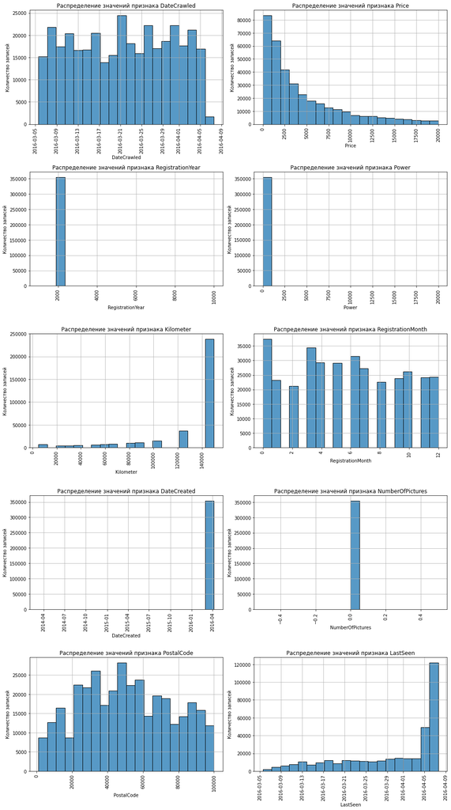

```python
data_research(data)
```

Моделей автомобилей очень много, что затрудняет их проверку на неявные дубликаты. Поэтому выведем отдельный список моделей для изучения уникальных значений по каждому бренду.

```python
for brand in data.sort_values(by='Brand')['Brand'].unique():
    print(brand)
    print(data[data['Brand'] == brand]\
          .sort_values(by='Model')['Model'].unique())
    print('\n')
```

```
alfa_romeo
['145' '147' '156' '159' 'other' 'spider' nan]


audi
['100' '200' '80' '90' 'a1' 'a2' 'a3' 'a4' 'a5' 'a6' 'a8' 'other' 'q3'
 'q5' 'q7' 'tt' nan]


bmw
['1er' '3er' '5er' '6er' '7er' 'i3' 'm_reihe' 'other' 'x_reihe' 'z_reihe'
 nan]


chevrolet
['aveo' 'captiva' 'matiz' 'other' 'spark' nan]


chrysler
['300c' 'crossfire' 'grand' 'other' 'ptcruiser' 'voyager' nan]


citroen
['berlingo' 'c1' 'c2' 'c3' 'c4' 'c5' 'other' nan]


dacia
['duster' 'lodgy' 'logan' 'other' 'sandero' nan]


daewoo
['kalos' 'lanos' 'matiz' 'nubira' 'other' nan]


daihatsu
['charade' 'cuore' 'materia' 'move' 'other' 'sirion' 'terios' nan]


fiat
['500' 'bravo' 'croma' 'doblo' 'ducato' 'other' 'panda' 'punto' 'seicento'
```

[output cut: 118 more lines]

```
['auris' 'avensis' 'aygo' 'corolla' 'other' 'rav' 'verso' 'yaris' nan]


trabant
['601' 'other' nan]


volkswagen
['amarok' 'beetle' 'bora' 'caddy' 'cc' 'eos' 'fox' 'golf' 'jetta' 'kaefer'
 'lupo' 'other' 'passat' 'phaeton' 'polo' 'scirocco' 'sharan' 'tiguan'
 'touareg' 'touran' 'transporter' 'up' nan]


volvo
['850' 'c_reihe' 'other' 's60' 'v40' 'v50' 'v60' 'v70' 'xc_reihe' nan]
```

### Вывод

Данные загружены, они соответствуют описанию задачи. Всего у нас представлено 354369 анкет, которые были зарегистрированы в период с 2014 по 2016 годы.

Типы данных соответствуют содержимому в столбцах.

Наименования столбцов не соответствуют стандартам оформления данных, необходимо привести названия к змеиному регистру.

Признаки `'DateCrawled'`, `'RegistrationMonth'`, `'DateCreated'`, `'NumberOfPictures'`, `'PostalCode'` и `'LastSeen'` для прогнозирования цены автомобиля не нужны, поэтому их стоит удалить.

Можно заметить, что в пяти столбцах имеются пропуски: `'VehicleType'`, `'Gearbox'`, `'Model'`, `'FuelType'`, `'Repaired'`. Далее мы вернемся к этим данным для более подробного изучения.

Были обнаружены 4 явных дубликата, которые необходимо изучить. Также среди уникальных значений столбца `'Brand'` обнаружен один неявный дубликат `'rover'`, который необходимо заменить на `'land_rover'`, а также в рамках этого же бренда имеется неявный дубликат модели `'rangerover'`, который нужно исправить на `'range_rover'`.

В столбцах `'RegistrationYear'`, `'Price'` и `'Power'` видны аномальные значения, а также значения, равные 0 в столбцах `'Price'` и `'Power'`. Это похоже на выбросы, их необходимо изучить подробнее.

Также среди брендов имеется значение `'sonstige_autos'`, что с немецкого переводится как "другие автомобили", т.е. бренды этих автомобилей не были указаны. Т.к. бренд имеет одно из важных значений для определения цены автомобиля, то стоит также изучить данные с этим значением.

Вернуться к содержанию

## Предобработка данных

Перед проведением предобработки сохраним размер изначальной таблицы.

```python
data_size = data.shape[0]
```

### Оформление столбцов

Приведем оформление наименований столбцов к змеиному регистру.

```python
data.columns = [re.sub(r'(?<!^)(?=[A-Z])', '_', col).lower()
                for col in data.columns]
```

Проверяем результат.

```python
data.columns
```

```
Index(['date_crawled', 'price', 'vehicle_type', 'registration_year', 'gearbox',
       'power', 'model', 'kilometer', 'registration_month', 'fuel_type',
       'brand', 'repaired', 'date_created', 'number_of_pictures',
       'postal_code', 'last_seen'],
      dtype='object')
```

### Удаление столбцов

Изменим порядок столбцов для более удобного ориентирования среди информации. В списке мы не будем упоминать признаки, которые не понадобятся для прогнозирования цены автомобиля:

- `'date_crawled'`,
- `'registration_month'`,
- `'date_created'`,
- `'number_of_pictures'`,
- `'postal_code'`,
- `'last_seen'`

```python
data = data.reindex(columns=['brand', 'model', 'registration_year',
                             'vehicle_type', 'gearbox', 'fuel_type',
                             'power', 'kilometer','repaired', 'price'])
```

Проверяем результат.

```python
data.head()
```

|  | brand | model | registration_year | vehicle_type | gearbox | fuel_type | power | kilometer | repaired | price |
| --- | --- | --- | --- | --- | --- | --- | --- | --- | --- | --- |
| 0 | volkswagen | golf | 1993 | NaN | manual | petrol | 0 | 150000 | NaN | 480 |
| 1 | audi | NaN | 2011 | coupe | manual | gasoline | 190 | 125000 | yes | 18300 |
| 2 | jeep | grand | 2004 | suv | auto | gasoline | 163 | 125000 | NaN | 9800 |
| 3 | volkswagen | golf | 2001 | small | manual | petrol | 75 | 150000 | no | 1500 |
| 4 | skoda | fabia | 2008 | small | manual | gasoline | 69 | 90000 | no | 3600 |

### Обработка неявных дубликатов

Значение бренда `'rover'` необходимо заменить на `'land_rover'`.

```python
for i in ['rover', 'land_rover']:
    print(f"Количество записей '{i}': "
          f"{data.loc[data['brand'] == i, 'brand'].count()}")
```

```
Количество записей 'rover': 486
Количество записей 'land_rover': 545
```

```python
data.loc[data['brand'] == 'rover', 'brand'] = 'land_rover'
```

Проверяем результат.

```python
for i in ['rover', 'land_rover']:
    print(f"Количество записей '{i}': "
          f"{data.loc[data['brand'] == i, 'brand'].count()}")
```

```
Количество записей 'rover': 0
Количество записей 'land_rover': 1031
```

Также среди моделей имеется неявный дубликат `'rangerover'`, который нужно исправить на `'range_rover'`.

```python
for i in ['rangerover', 'range_rover']:
    print(f"Количество записей '{i}': "
          f"{data.loc[data['model'] == i, 'model'].count()}")
```

```
Количество записей 'rangerover': 4
Количество записей 'range_rover': 77
```

```python
data.loc[data['model'] == 'rangerover', 'model'] = 'range_rover'
```

Проверяем результат.

```python
for i in ['rangerover', 'range_rover']:
    print(f"Количество записей '{i}': "
          f"{data.loc[data['model'] == i, 'model'].count()}")
```

```
Количество записей 'rangerover': 0
Количество записей 'range_rover': 81
```

### Обработка пропущенных значений

Изучим данные по каждому столбцу с пропущенными значениями.

```python
for column in data.columns:

    if data[column].isna().sum() != 0:

        display(HTML(f'<br><h3>Столбец "{column}"</h3>'))

        count_n_display(data.loc[data[column].isna()])

    else: pass
```

Столбец "model"

```
Количество записей: 19705
Доля таких записей: 5.56%
```

|  | brand | model | registration_year | vehicle_type | gearbox | fuel_type | power | kilometer | repaired | price |
| --- | --- | --- | --- | --- | --- | --- | --- | --- | --- | --- |
| 1 | audi | NaN | 2011 | coupe | manual | gasoline | 190 | 125000 | yes | 18300 |
| 59 | sonstige_autos | NaN | 1994 | suv | manual | NaN | 286 | 150000 | NaN | 1 |
| 81 | fiat | NaN | 1997 | small | manual | NaN | 54 | 150000 | yes | 350 |
| 115 | volkswagen | NaN | 1999 | small | NaN | petrol | 0 | 5000 | NaN | 0 |
| 135 | audi | NaN | 1992 | sedan | manual | NaN | 136 | 150000 | no | 1450 |

Столбец "vehicle_type"

```
Количество записей: 37490
Доля таких записей: 10.58%
```

|  | brand | model | registration_year | vehicle_type | gearbox | fuel_type | power | kilometer | repaired | price |
| --- | --- | --- | --- | --- | --- | --- | --- | --- | --- | --- |
| 0 | volkswagen | golf | 1993 | NaN | manual | petrol | 0 | 150000 | NaN | 480 |
| 16 | volkswagen | polo | 2016 | NaN | NaN | petrol | 60 | 150000 | NaN | 300 |
| 22 | opel | meriva | 2018 | NaN | manual | petrol | 90 | 150000 | no | 2900 |
| 26 | citroen | c4 | 2017 | NaN | manual | NaN | 125 | 125000 | no | 5555 |
| 31 | renault | clio | 2016 | NaN | manual | petrol | 60 | 150000 | NaN | 899 |

Столбец "gearbox"

```
Количество записей: 19833
Доля таких записей: 5.6%
```

|  | brand | model | registration_year | vehicle_type | gearbox | fuel_type | power | kilometer | repaired | price |
| --- | --- | --- | --- | --- | --- | --- | --- | --- | --- | --- |
| 15 | ford | ka | 1910 | small | NaN | petrol | 0 | 5000 | NaN | 450 |
| 16 | volkswagen | polo | 2016 | NaN | NaN | petrol | 60 | 150000 | NaN | 300 |
| 32 | volkswagen | golf | 1994 | sedan | NaN | petrol | 0 | 150000 | no | 245 |
| 37 | renault | kangoo | 2016 | NaN | NaN | gasoline | 0 | 150000 | no | 1500 |
| 40 | opel | corsa | 1990 | NaN | NaN | petrol | 0 | 150000 | NaN | 0 |

Столбец "fuel_type"

```
Количество записей: 32895
Доля таких записей: 9.28%
```

|  | brand | model | registration_year | vehicle_type | gearbox | fuel_type | power | kilometer | repaired | price |
| --- | --- | --- | --- | --- | --- | --- | --- | --- | --- | --- |
| 9 | volkswagen | golf | 1998 | small | manual | NaN | 101 | 150000 | NaN | 999 |
| 13 | volkswagen | passat | 2004 | wagon | manual | NaN | 131 | 150000 | no | 2500 |
| 26 | citroen | c4 | 2017 | NaN | manual | NaN | 125 | 125000 | no | 5555 |
| 36 | opel | kadett | 1991 | other | manual | NaN | 75 | 70000 | NaN | 1600 |
| 41 | mercedes_benz | e_klasse | 2002 | sedan | auto | NaN | 306 | 150000 | NaN | 7500 |

Столбец "repaired"

```
Количество записей: 71154
Доля таких записей: 20.08%
```

|  | brand | model | registration_year | vehicle_type | gearbox | fuel_type | power | kilometer | repaired | price |
| --- | --- | --- | --- | --- | --- | --- | --- | --- | --- | --- |
| 0 | volkswagen | golf | 1993 | NaN | manual | petrol | 0 | 150000 | NaN | 480 |
| 2 | jeep | grand | 2004 | suv | auto | gasoline | 163 | 125000 | NaN | 9800 |
| 8 | ford | c_max | 2014 | bus | manual | petrol | 125 | 30000 | NaN | 14500 |
| 9 | volkswagen | golf | 1998 | small | manual | NaN | 101 | 150000 | NaN | 999 |
| 12 | volkswagen | passat | 1995 | wagon | manual | petrol | 115 | 150000 | NaN | 999 |

Данные выглядят корректно, но количество пропусков довольно значительное, особенно в столбце `'repaired'`. При изучении информации мы выяснили, что 30.6% записей в таблице имеет хотя бы один пропуск. Посмотрим, какую долю занимают все данные с пропущенными значениями без учета `'repaired'`.

```python
display(HTML(f'<br><h3>Данные с пропущенными значениями без учета столбца`repaired`</h3>'))
count_n_display(
    data[
        (data[['model',
               'vehicle_type',
               'gearbox',
               'fuel_type']]
         .isna().any(axis=1))])
```

Данные с пропущенными значениями без учета столбца`repaired`

```
Количество записей: 70243
Доля таких записей: 19.82%
```

|  | brand | model | registration_year | vehicle_type | gearbox | fuel_type | power | kilometer | repaired | price |
| --- | --- | --- | --- | --- | --- | --- | --- | --- | --- | --- |
| 0 | volkswagen | golf | 1993 | NaN | manual | petrol | 0 | 150000 | NaN | 480 |
| 1 | audi | NaN | 2011 | coupe | manual | gasoline | 190 | 125000 | yes | 18300 |
| 9 | volkswagen | golf | 1998 | small | manual | NaN | 101 | 150000 | NaN | 999 |
| 13 | volkswagen | passat | 2004 | wagon | manual | NaN | 131 | 150000 | no | 2500 |
| 15 | ford | ka | 1910 | small | NaN | petrol | 0 | 5000 | NaN | 450 |

Количество данных с пропущенными значениями в обоих случаях слишком большой. Их удалить не получится, т.к. мы потеряем очень большой объем данных.

Признаки `'vehicle_type'`, `'gearbox'` и `'fuel_type'` относятся к характеристикам модели автомобиля, поэтому пропуски в них можно заполнить наиболее часто встречающимся значением у конкретной модели. Но предварительно выявим и удалим наименее информативные записи, в которых нам не получится восстановить эти данные.

Проверим все данные, имеющие в столбце `'model'` пропуски или значение `'other'`, которые имеют хотя бы один пропуск в признаках `'vehicle_type'`, `'gearbox'` и `'fuel_type'`.

```python
n = data[
    ((data['model'] == 'other') | data['model'].isna()) &
     (data[['vehicle_type',
            'gearbox',
            'fuel_type']]
      .isna().any(axis=1))]

count_n_display(n)
```

```
Количество записей: 13573
Доля таких записей: 3.83%
```

|  | brand | model | registration_year | vehicle_type | gearbox | fuel_type | power | kilometer | repaired | price |
| --- | --- | --- | --- | --- | --- | --- | --- | --- | --- | --- |
| 52 | hyundai | other | 2016 | NaN | manual | NaN | 55 | 5000 | NaN | 1400 |
| 57 | seat | other | 2018 | NaN | manual | NaN | 64 | 125000 | no | 2399 |
| 59 | sonstige_autos | NaN | 1994 | suv | manual | NaN | 286 | 150000 | NaN | 1 |
| 81 | fiat | NaN | 1997 | small | manual | NaN | 54 | 150000 | yes | 350 |
| 115 | volkswagen | NaN | 1999 | small | NaN | petrol | 0 | 5000 | NaN | 0 |

Такие данные несут мало ценной информации, и т.к. их доля составляет всего 3.83%, то мы их можем удалить.

```python
print('Размер датафрейма до удаления данных:', data.shape[0])

data = data.drop(n.index, axis=0)

print('Размер датафрейма после удаления данных:', data.shape[0])
```

```
Размер датафрейма до удаления данных: 354369
Размер датафрейма после удаления данных: 340796
```

Данные удалены, теперь мы можем приступить к заполнению оставшихся пропусков в датафрейме. Сперва выведем первые 20 строк датафрейма, чтобы после заполнения данных можно было сравнить результат.

```python
data.head(20)
```

|  | brand | model | registration_year | vehicle_type | gearbox | fuel_type | power | kilometer | repaired | price |
| --- | --- | --- | --- | --- | --- | --- | --- | --- | --- | --- |
| 0 | volkswagen | golf | 1993 | NaN | manual | petrol | 0 | 150000 | NaN | 480 |
| 1 | audi | NaN | 2011 | coupe | manual | gasoline | 190 | 125000 | yes | 18300 |
| 2 | jeep | grand | 2004 | suv | auto | gasoline | 163 | 125000 | NaN | 9800 |
| 3 | volkswagen | golf | 2001 | small | manual | petrol | 75 | 150000 | no | 1500 |
| 4 | skoda | fabia | 2008 | small | manual | gasoline | 69 | 90000 | no | 3600 |
| 5 | bmw | 3er | 1995 | sedan | manual | petrol | 102 | 150000 | yes | 650 |
| 6 | peugeot | 2_reihe | 2004 | convertible | manual | petrol | 109 | 150000 | no | 2200 |
| 7 | volkswagen | other | 1980 | sedan | manual | petrol | 50 | 40000 | no | 0 |
| 8 | ford | c_max | 2014 | bus | manual | petrol | 125 | 30000 | NaN | 14500 |
| 9 | volkswagen | golf | 1998 | small | manual | NaN | 101 | 150000 | NaN | 999 |
| 10 | mazda | 3_reihe | 2004 | sedan | manual | petrol | 105 | 150000 | no | 2000 |
| 11 | volkswagen | passat | 2005 | wagon | manual | gasoline | 140 | 150000 | yes | 2799 |
| 12 | volkswagen | passat | 1995 | wagon | manual | petrol | 115 | 150000 | NaN | 999 |
| 13 | volkswagen | passat | 2004 | wagon | manual | NaN | 131 | 150000 | no | 2500 |
| 14 | nissan | navara | 2011 | suv | manual | gasoline | 190 | 70000 | no | 17999 |
| 15 | ford | ka | 1910 | small | NaN | petrol | 0 | 5000 | NaN | 450 |
| 16 | volkswagen | polo | 2016 | NaN | NaN | petrol | 60 | 150000 | NaN | 300 |
| 17 | renault | twingo | 2004 | small | auto | petrol | 75 | 150000 | no | 1750 |
| 18 | ford | c_max | 2007 | bus | manual | gasoline | 136 | 150000 | no | 7550 |
| 19 | mercedes_benz | a_klasse | 2004 | bus | manual | petrol | 102 | 150000 | no | 1850 |

Заполним оставшиеся пропуски в столбце `'model'` значением `'other'`.

```python
print('Количество пропусков в столбце до заполнения:',
      data['model'].isna().sum())

data['model'] = data['model'].fillna('other')

print('Количество пропусков в столбце после заполнения:',
      data['model'].isna().sum())
```

```
Количество пропусков в столбце до заполнения: 9439
Количество пропусков в столбце после заполнения: 0
```

Заполним пропуски в столбце `'repaired'` значением `'unknown'`.

```python
print('Количество пропусков в столбце до заполнения:',
      data['repaired'].isna().sum())

data['repaired'] = data['repaired'].fillna('unknown')

print('Количество пропусков в столбце после заполнения:',
      data['repaired'].isna().sum())
```

```
Количество пропусков в столбце до заполнения: 63414
Количество пропусков в столбце после заполнения: 0
```

Заполним пропуски по типу кузова, коробки передач и топлива наиболее часто встречающимися значениями по каждой модели автомобиля.

```python
print('Количество записей с хотя бы одним пропуском до заполнения:',
      data[data.isna().any(axis=1)].shape[0])

data.update(
    data.groupby(['brand', 'model']
                ).transform(
        lambda x: x.fillna(x.mode().iloc[0])
    ))

print('Количество записей с хотя бы одним пропуском после заполнения:',
      data[data.isna().any(axis=1)].shape[0])
```

```
Количество записей с хотя бы одним пропуском до заполнения: 47231
Количество записей с хотя бы одним пропуском после заполнения: 0
```

Проверяем количество пропусков и корректность отображения данных.

```python
print('Количество пропусков в датафрейме:',
      data.isna().sum().sum())

data.head(20)
```

```
Количество пропусков в датафрейме: 0
```

|  | brand | model | registration_year | vehicle_type | gearbox | fuel_type | power | kilometer | repaired | price |
| --- | --- | --- | --- | --- | --- | --- | --- | --- | --- | --- |
| 0 | volkswagen | golf | 1993 | sedan | manual | petrol | 0 | 150000 | unknown | 480 |
| 1 | audi | other | 2011 | coupe | manual | gasoline | 190 | 125000 | yes | 18300 |
| 2 | jeep | grand | 2004 | suv | auto | gasoline | 163 | 125000 | unknown | 9800 |
| 3 | volkswagen | golf | 2001 | small | manual | petrol | 75 | 150000 | no | 1500 |
| 4 | skoda | fabia | 2008 | small | manual | gasoline | 69 | 90000 | no | 3600 |
| 5 | bmw | 3er | 1995 | sedan | manual | petrol | 102 | 150000 | yes | 650 |
| 6 | peugeot | 2_reihe | 2004 | convertible | manual | petrol | 109 | 150000 | no | 2200 |
| 7 | volkswagen | other | 1980 | sedan | manual | petrol | 50 | 40000 | no | 0 |
| 8 | ford | c_max | 2014 | bus | manual | petrol | 125 | 30000 | unknown | 14500 |
| 9 | volkswagen | golf | 1998 | small | manual | petrol | 101 | 150000 | unknown | 999 |
| 10 | mazda | 3_reihe | 2004 | sedan | manual | petrol | 105 | 150000 | no | 2000 |
| 11 | volkswagen | passat | 2005 | wagon | manual | gasoline | 140 | 150000 | yes | 2799 |
| 12 | volkswagen | passat | 1995 | wagon | manual | petrol | 115 | 150000 | unknown | 999 |
| 13 | volkswagen | passat | 2004 | wagon | manual | gasoline | 131 | 150000 | no | 2500 |
| 14 | nissan | navara | 2011 | suv | manual | gasoline | 190 | 70000 | no | 17999 |
| 15 | ford | ka | 1910 | small | manual | petrol | 0 | 5000 | unknown | 450 |
| 16 | volkswagen | polo | 2016 | small | manual | petrol | 60 | 150000 | unknown | 300 |
| 17 | renault | twingo | 2004 | small | auto | petrol | 75 | 150000 | no | 1750 |
| 18 | ford | c_max | 2007 | bus | manual | gasoline | 136 | 150000 | no | 7550 |
| 19 | mercedes_benz | a_klasse | 2004 | bus | manual | petrol | 102 | 150000 | no | 1850 |

### Обработка аномальных значений

#### Столбец `'price'`

Изучим автомобили, цена которых равна 0.

```python
count_n_display(
    data[data['price'] == 0]
    )
```

```
Количество записей: 8832
Доля таких записей: 2.49%
```

|  | brand | model | registration_year | vehicle_type | gearbox | fuel_type | power | kilometer | repaired | price |
| --- | --- | --- | --- | --- | --- | --- | --- | --- | --- | --- |
| 7 | volkswagen | other | 1980 | sedan | manual | petrol | 50 | 40000 | no | 0 |
| 40 | opel | corsa | 1990 | small | manual | petrol | 0 | 150000 | unknown | 0 |
| 111 | volkswagen | golf | 2017 | sedan | manual | petrol | 0 | 5000 | unknown | 0 |
| 152 | opel | meriva | 2004 | bus | manual | lpg | 101 | 150000 | yes | 0 |
| 231 | ford | mondeo | 2001 | wagon | manual | petrol | 115 | 150000 | unknown | 0 |

Т.к. стоимость является целевым признаком, то мы не сможем заполнить пропуски, т.к. это исказит предсказания модели. Таких данных немного, поэтому мы можем их удалить.

```python
data = data.loc[data['price'] > 0]
```

Также в таблице присутствуют автомобили с аномально низкой стоимостью. В зависимости от состояния автомобиля недорогие модели действительно могут продавать еще более дешево, но некоторые ставят очень низкую цену для привлечения большего внимания к своему объявлению и обходу фильтров по цене.

Изучим автомобили, которые имеют стоимость не более 250 евро.

```python
count_n_display(
    data[(data['price'] >= 0) & (data['price'] < 250)]
    )
```

```
Количество записей: 8100
Доля таких записей: 2.29%
```

|  | brand | model | registration_year | vehicle_type | gearbox | fuel_type | power | kilometer | repaired | price |
| --- | --- | --- | --- | --- | --- | --- | --- | --- | --- | --- |
| 32 | volkswagen | golf | 1994 | sedan | manual | petrol | 0 | 150000 | no | 245 |
| 60 | bmw | 3er | 1995 | coupe | manual | petrol | 102 | 150000 | unknown | 200 |
| 79 | opel | astra | 2016 | sedan | manual | petrol | 75 | 150000 | yes | 150 |
| 89 | mercedes_benz | e_klasse | 1995 | sedan | manual | gasoline | 113 | 150000 | no | 1 |
| 145 | audi | 100 | 1985 | sedan | manual | petrol | 0 | 150000 | unknown | 150 |

Таких автомобилей немного. Нужно избавиться от таких объявлений, поэтому ограничим минимальную стоимость автомобилей до 250 евро.

```python
data = data.loc[data['price'] > 250]
```

Проверяем результат.

```python
print('Количество записей:',
      data[(data['price'] >= 0) & (data['price'] < 250)].shape[0])
```

```
Количество записей: 0
```

#### Столбец `'power'`

Изучим автомобили, мощность которых равна 0.

```python
count_n_display(
    data[data['power'] == 0]
    )
```

```
Количество записей: 27988
Доля таких записей: 7.9%
```

|  | brand | model | registration_year | vehicle_type | gearbox | fuel_type | power | kilometer | repaired | price |
| --- | --- | --- | --- | --- | --- | --- | --- | --- | --- | --- |
| 0 | volkswagen | golf | 1993 | sedan | manual | petrol | 0 | 150000 | unknown | 480 |
| 15 | ford | ka | 1910 | small | manual | petrol | 0 | 5000 | unknown | 450 |
| 37 | renault | kangoo | 2016 | bus | manual | gasoline | 0 | 150000 | no | 1500 |
| 54 | opel | signum | 2005 | wagon | manual | gasoline | 0 | 150000 | no | 4700 |
| 55 | opel | astra | 1999 | wagon | manual | gasoline | 0 | 150000 | yes | 550 |

Таких записей довольно много, удалять их не стоит. Лучше всего их заполнить медианой, но вернемся к этому чуть позже.

Пока заменим нули на пропуски, чтобы они не влияли на значение медианы.

```python
data.loc[data['power'] == 0, 'power'] = np.nan
```

Отметим как аномальные значения мощность менее 40 л.с. и более 600 л.с. Изучим эти записи.

```python
count_n_display(
    data[(data['power'] < 40) | (data['power'] > 600)]
    )
```

```
Количество записей: 1459
Доля таких записей: 0.41%
```

|  | brand | model | registration_year | vehicle_type | gearbox | fuel_type | power | kilometer | repaired | price |
| --- | --- | --- | --- | --- | --- | --- | --- | --- | --- | --- |
| 431 | sonstige_autos | other | 2004 | small | auto | gasoline | 5.0 | 70000 | no | 3950 |
| 844 | fiat | other | 1998 | small | manual | petrol | 39.0 | 80000 | no | 500 |
| 1235 | fiat | 500 | 1971 | small | manual | petrol | 23.0 | 70000 | no | 4450 |
| 1527 | opel | corsa | 1992 | small | manual | petrol | 33.0 | 150000 | unknown | 750 |
| 1816 | toyota | corolla | 2004 | small | manual | petrol | 1398.0 | 5000 | no | 3200 |

Таких значений совсем немного, поэтому мы также заменим их на пропуски.

```python
data.loc[(data['power'] < 40) |
         (data['power'] > 600),
         'power'] = np.nan
```

Избавившись от аномальных значений, теперь мы можем рассчитать медиану по каждой модели автомобиля и заполнить пропуски в столбце полученными значениями.

```python
print('Количество пропусков в столбце до заполнения:',
      data[data['power'].isna()].shape[0])

data['power'] = data.groupby(['brand', 'model'])['power']\
                    .transform(lambda x: x.fillna(x.median()))

print('Количество пропусков в столбце после заполнения:',
      data[data['power'].isna()].shape[0])
```

```
Количество пропусков в столбце до заполнения: 29447
Количество пропусков в столбце после заполнения: 1
```

Осталась одна запись с пропуском. Взглянем на неё.

```python
data[data['power'].isna()]
```

|  | brand | model | registration_year | vehicle_type | gearbox | fuel_type | power | kilometer | repaired | price |
| --- | --- | --- | --- | --- | --- | --- | --- | --- | --- | --- |
| 234296 | land_rover | serie_1 | 1978 | wagon | manual | gasoline | NaN | 30000 | unknown | 3800 |

Проверим, нет ли других автомобилей такой же модели в датафрейме.

```python
data[data['model'] == 'serie_1']
```

|  | brand | model | registration_year | vehicle_type | gearbox | fuel_type | power | kilometer | repaired | price |
| --- | --- | --- | --- | --- | --- | --- | --- | --- | --- | --- |
| 234296 | land_rover | serie_1 | 1978 | wagon | manual | gasoline | NaN | 30000 | unknown | 3800 |

Действительно, такая модель в датафрейме упоминается лишь один раз и медиану по ней вычислить было невозможно. Эту запись мы можем заполнить вручную.

```python
data.loc[data['model'] == 'serie_1', 'power'] = 50
```

Проверяем результат.

```python
data[data['model'] == 'serie_1']
```

|  | brand | model | registration_year | vehicle_type | gearbox | fuel_type | power | kilometer | repaired | price |
| --- | --- | --- | --- | --- | --- | --- | --- | --- | --- | --- |
| 234296 | land_rover | serie_1 | 1978 | wagon | manual | gasoline | 50.0 | 30000 | unknown | 3800 |

#### Столбец `'registration_year'`

Изучим автомобили, у которых указан аномальный год регистрации.

Данные были актуальны на момент 2016 года, поэтому всё, что больше - аномалия. Также нижнюю границу мы проведем на 1960 году, т.к. старые ретро-автомобили имеют совсем другие правила ценообразования.

```python
count_n_display(
    data[(data['registration_year'] > 2016) |
         (data['registration_year'] < 1960)]
    )
```

```
Количество записей: 11394
Доля таких записей: 3.22%
```

|  | brand | model | registration_year | vehicle_type | gearbox | fuel_type | power | kilometer | repaired | price |
| --- | --- | --- | --- | --- | --- | --- | --- | --- | --- | --- |
| 15 | ford | ka | 1910 | small | manual | petrol | 60.0 | 5000 | unknown | 450 |
| 22 | opel | meriva | 2018 | bus | manual | petrol | 90.0 | 150000 | no | 2900 |
| 26 | citroen | c4 | 2017 | sedan | manual | gasoline | 125.0 | 125000 | no | 5555 |
| 48 | volkswagen | golf | 2017 | sedan | manual | petrol | 80.0 | 100000 | unknown | 7750 |
| 51 | fiat | punto | 2017 | small | manual | gasoline | 90.0 | 150000 | yes | 2000 |

В датафрейме можно заметить, что многие автомобили, у которых указан год ранее 1960-х на самом деле являются более современными, что тоже говорит об аномалиях, поэтому мы будем обрабатывать их соотвествующе. В данном случае мы также можем заполнить аномалии медианой. Заменим некорректные значения на пропуски.

```python
data.loc[(data['registration_year'] < 1960) |
         (data['registration_year'] > 2016),
         'registration_year'] = np.nan
```

Рассчитаем медиану по каждой модели автомобиля и заполним пропуски в столбце полученными значениями.

```python
print('Количество пропусков в столбце до заполнения:',
      data[data['registration_year'].isna()].shape[0])

data['registration_year'] = data.groupby(['brand', 'model'])['registration_year']\
                                .transform(lambda x: x.fillna(x.median()))

print('Количество пропусков в столбце после заполнения:',
      data[data['registration_year'].isna()].shape[0])
```

```
Количество пропусков в столбце до заполнения: 11394
Количество пропусков в столбце после заполнения: 0
```

Проверим, остались ли после заполнения медианой автомобили от 1960-х и ранее.

```python
count_n_display(data[data['registration_year'] < 1960])
```

```
Количество записей: 0
Доля таких записей: 0.0%
```

|  | brand | model | registration_year | vehicle_type | gearbox | fuel_type | power | kilometer | repaired | price |
| --- | --- | --- | --- | --- | --- | --- | --- | --- | --- | --- |

Заменим тип данных в столбцах `'registration_year'` и `'power'` с `flaot64` на `int64`.

```python
data[['registration_year', 'power']] = data[['registration_year', 'power']].astype('int64')
```

#### Столбец `'brand'`

Изучим автомобили, у которых не указан бренд.

```python
count_n_display(
    data[data['brand'] == 'sonstige_autos']
    )
```

```
Количество записей: 1840
Доля таких записей: 0.52%
```

|  | brand | model | registration_year | vehicle_type | gearbox | fuel_type | power | kilometer | repaired | price |
| --- | --- | --- | --- | --- | --- | --- | --- | --- | --- | --- |
| 431 | sonstige_autos | other | 2004 | small | auto | gasoline | 155 | 70000 | no | 3950 |
| 661 | sonstige_autos | other | 2000 | suv | auto | lpg | 250 | 150000 | no | 9900 |
| 700 | sonstige_autos | other | 2010 | sedan | auto | petrol | 186 | 125000 | no | 6999 |
| 985 | sonstige_autos | other | 2010 | sedan | manual | petrol | 101 | 70000 | yes | 500 |
| 999 | sonstige_autos | other | 1990 | wagon | manual | petrol | 155 | 30000 | unknown | 3900 |

Такие данные представляют из себя сборную солянку, по таким будет сложно предсказать цену. Удалим их во избежание искажения резульатов модели.

```python
data = data.loc[data['brand'] != 'sonstige_autos']
```

Проверяем результат.

```python
print('Количество записей:',
      data[data['brand'] == 'sonstige_autos'].shape[0])
```

```
Количество записей: 0
```

Проверим, насколько уменьшилось количество записей в датафрейме.

```python
print(f'Количество удаленных записей из датафрейма: '
      f'{data_size - data.shape[0]} '
      f'({round((data_size - data.shape[0]) / data_size * 100, 2)}%)')
```

```
Количество удаленных записей из датафрейма: 34347 (9.69%)
```

### Обработка явных дубликатов

При первичном изучении информации о датафрейме было обнаружено 4 дубликата. Проверим, изменилось ли их количество после проведения предобработки.

```python
print(f'Количество дубликатов в датафрейме: {data.duplicated().sum()} '
      f'({(data.duplicated().sum() / data_size):.2%})')
```

```
Количество дубликатов в датафрейме: 47431 (13.38%)
```

Дубликатов стало кратно больше, что неудивительно, т.к. мы удалили ряд признаков, которые делали записи уникальными. Взглянем на них.

```python
data[data.duplicated(keep=False)].sort_values(by='model').head(10)
```

|  | brand | model | registration_year | vehicle_type | gearbox | fuel_type | power | kilometer | repaired | price |
| --- | --- | --- | --- | --- | --- | --- | --- | --- | --- | --- |
| 290498 | audi | 100 | 1973 | sedan | manual | petrol | 101 | 80000 | no | 2200 |
| 313979 | audi | 100 | 1993 | sedan | manual | petrol | 150 | 150000 | no | 1499 |
| 72618 | audi | 100 | 1994 | sedan | manual | petrol | 150 | 150000 | no | 1555 |
| 103126 | audi | 100 | 1991 | sedan | manual | petrol | 134 | 150000 | no | 1049 |
| 241769 | audi | 100 | 1991 | sedan | manual | petrol | 133 | 150000 | no | 2000 |
| 172058 | audi | 100 | 1973 | sedan | manual | petrol | 101 | 80000 | no | 2200 |
| 71734 | audi | 100 | 1993 | wagon | manual | petrol | 133 | 150000 | no | 2400 |
| 32200 | audi | 100 | 1991 | sedan | auto | petrol | 98 | 150000 | unknown | 990 |
| 220530 | audi | 100 | 1991 | sedan | manual | petrol | 133 | 150000 | no | 2500 |
| 129517 | audi | 100 | 1993 | wagon | manual | petrol | 150 | 150000 | no | 2000 |

Конечно, это не дубликаты одной анкеты, ведь характеристики машины могут совпадать у нескольких людей.

Но дубликаты увеличивают вес одинаковых записей для модели ML, что может привести к ее переобучению и ухудшению ее обобщающей способности.

Удаление 13.38% дубликатов может существенно сократить время обработки и улучшить производительность моделей. Т.к. эти записи не несут дополнительной информации, то мы можем их удалить.

```python
data = data.drop_duplicates().reset_index(drop=True)
```

Проверяем результат.

```python
print(f'Количество дубликатов в датафрейме: {data.duplicated().sum()} '
      f'({(data.duplicated().sum() / data_size):.2%})')
```

```
Количество дубликатов в датафрейме: 0 (0.00%)
```

### Вывод

Проверим, насколько уменьшилось количество записей в датафрейме.

```python
print(f'Количество удаленных записей из датафрейма: '
      f'{data_size - data.shape[0]} '
      f'({round((data_size - data.shape[0]) / data_size * 100, 2)}%)')
```

```
Количество удаленных записей из датафрейма: 81778 (23.08%)
```

Еще раз проверим общую информацию о датафрейме после проведения предобработки данных.

|  | brand | model | registration_year | vehicle_type | gearbox | fuel_type | power | kilometer | repaired | price |
| --- | --- | --- | --- | --- | --- | --- | --- | --- | --- | --- |
| 0 | volkswagen | golf | 1993 | sedan | manual | petrol | 101 | 150000 | unknown | 480 |
| 1 | audi | other | 2011 | coupe | manual | gasoline | 190 | 125000 | yes | 18300 |
| 2 | jeep | grand | 2004 | suv | auto | gasoline | 163 | 125000 | unknown | 9800 |
| 3 | volkswagen | golf | 2001 | small | manual | petrol | 75 | 150000 | no | 1500 |
| 4 | skoda | fabia | 2008 | small | manual | gasoline | 69 | 90000 | no | 3600 |

|  | brand | model | registration_year | vehicle_type | gearbox | fuel_type | power | kilometer | repaired | price |
| --- | --- | --- | --- | --- | --- | --- | --- | --- | --- | --- |
| 272586 | alfa_romeo | 159 | 2016 | wagon | auto | gasoline | 150 | 150000 | no | 5250 |
| 272587 | seat | leon | 2004 | sedan | manual | petrol | 225 | 150000 | yes | 3200 |
| 272588 | smart | fortwo | 2000 | convertible | auto | petrol | 101 | 125000 | no | 1199 |
| 272589 | volkswagen | transporter | 1996 | bus | manual | gasoline | 102 | 150000 | no | 9200 |
| 272590 | volkswagen | golf | 2002 | wagon | manual | gasoline | 100 | 150000 | unknown | 3400 |

Общая информация о данных

```
<class 'pandas.core.frame.DataFrame'>
RangeIndex: 272591 entries, 0 to 272590
Data columns (total 10 columns):
 #   Column             Non-Null Count   Dtype
---  ------             --------------   -----
 0   brand              272591 non-null  object
 1   model              272591 non-null  object
 2   registration_year  272591 non-null  int64
 3   vehicle_type       272591 non-null  object
 4   gearbox            272591 non-null  object
 5   fuel_type          272591 non-null  object
 6   power              272591 non-null  int64
 7   kilometer          272591 non-null  int64
 8   repaired           272591 non-null  object
 9   price              272591 non-null  int64
dtypes: int64(4), object(6)
memory usage: 20.8+ MB
None
```

Наименования столбцов

```
Index(['brand', 'model', 'registration_year', 'vehicle_type', 'gearbox',
       'fuel_type', 'power', 'kilometer', 'repaired', 'price'],
      dtype='object')
```

Количество и доля пропущенных значений

```
Пропуски отсутствуют
```

Количество дубликатов в датафрейме

```
Всего: 0 (0.00% от общего размера)
```

Уникальные значения в датафрейме

**Уникальные значения в столбце "brand":** 38

```
['alfa_romeo' 'audi' 'bmw' 'chevrolet' 'chrysler' 'citroen' 'dacia'
 'daewoo' 'daihatsu' 'fiat' 'ford' 'honda' 'hyundai' 'jaguar' 'jeep' 'kia'
 'lada' 'lancia' 'land_rover' 'mazda' 'mercedes_benz' 'mini' 'mitsubishi'
 'nissan' 'opel' 'peugeot' 'porsche' 'renault' 'saab' 'seat' 'skoda'
 'smart' 'subaru' 'suzuki' 'toyota' 'trabant' 'volkswagen' 'volvo']
```

**Уникальные значения в столбце "model":** 249

```
['100' '145' '147' '156' '159' '1_reihe' '1er' '200' '2_reihe' '300c'
 '3_reihe' '3er' '4_reihe' '500' '5_reihe' '5er' '601' '6_reihe' '6er'
 '7er' '80' '850' '90' '900' '9000' '911' 'a1' 'a2' 'a3' 'a4' 'a5' 'a6'
 'a8' 'a_klasse' 'accord' 'agila' 'alhambra' 'almera' 'altea' 'amarok'
 'antara' 'arosa' 'astra' 'auris' 'avensis' 'aveo' 'aygo' 'b_klasse'
 'b_max' 'beetle' 'berlingo' 'bora' 'boxster' 'bravo' 'c1' 'c2' 'c3' 'c4'
 'c5' 'c_klasse' 'c_max' 'c_reihe' 'caddy' 'calibra' 'captiva' 'carisma'
 'carnival' 'cayenne' 'cc' 'ceed' 'charade' 'cherokee' 'citigo' 'civic'
 'cl' 'clio' 'clk' 'clubman' 'colt' 'combo' 'cooper' 'cordoba' 'corolla'
 'corsa' 'cr_reihe' 'croma' 'crossfire' 'cuore' 'cx_reihe' 'defender'
 'delta' 'discovery' 'doblo' 'ducato' 'duster' 'e_klasse' 'elefantino'
 'eos' 'escort' 'espace' 'exeo' 'fabia' 'fiesta' 'focus' 'forester'
 'forfour' 'fortwo' 'fox' 'freelander' 'fusion' 'g_klasse' 'galant'
 'galaxy' 'getz' 'gl' 'glk' 'golf' 'grand' 'i3' 'i_reihe' 'ibiza'
 'impreza' 'insignia' 'jazz' 'jetta' 'jimny' 'juke' 'justy' 'ka' 'kadett'
 'kaefer' 'kalina' 'kalos' 'kangoo' 'kappa' 'kuga' 'laguna' 'lancer'
 'lanos' 'legacy' 'leon' 'lodgy' 'logan' 'lupo' 'lybra' 'm_klasse'
 'm_reihe' 'materia' 'matiz' 'megane' 'meriva' 'micra' 'mii' 'modus'
 'mondeo' 'move' 'musa' 'mustang' 'mx_reihe' 'navara' 'niva' 'note'
 'nubira' 'octavia' 'omega' 'one' 'other' 'outlander' 'pajero' 'panda'
 'passat' 'phaeton' 'picanto' 'polo' 'primera' 'ptcruiser' 'punto' 'q3'
 'q5' 'q7' 'qashqai' 'r19' 'range_rover' 'range_rover_evoque'
 'range_rover_sport' 'rav' 'rio' 'roadster' 'roomster' 'rx_reihe' 's60'
 's_klasse' 's_max' 's_type' 'samara' 'sandero' 'santa' 'scenic'
 'scirocco' 'seicento' 'serie_1' 'serie_2' 'serie_3' 'sharan' 'signum'
 'sirion' 'sl' 'slk' 'sorento' 'spark' 'spider' 'sportage' 'sprinter'
 'stilo' 'superb' 'swift' 'terios' 'tigra' 'tiguan' 'toledo' 'touareg'
 'touran' 'transit' 'transporter' 'tt' 'tucson' 'twingo' 'up' 'v40' 'v50'
 'v60' 'v70' 'v_klasse' 'vectra' 'verso' 'viano' 'vito' 'vivaro' 'voyager'
 'wrangler' 'x_reihe' 'x_trail' 'x_type' 'xc_reihe' 'yaris' 'yeti'
 'ypsilon' 'z_reihe' 'zafira']
```

**Уникальные значения в столбце "registration_year":** 57

```
[1960 1961 1962 1963 1964 1965 1966 1967 1968 1969 1970 1971 1972 1973
 1974 1975 1976 1977 1978 1979 1980 1981 1982 1983 1984 1985 1986 1987
 1988 1989 1990 1991 1992 1993 1994 1995 1996 1997 1998 1999 2000 2001
 2002 2003 2004 2005 2006 2007 2008 2009 2010 2011 2012 2013 2014 2015
 2016]
```

**Уникальные значения в столбце "vehicle_type":** 8

```
['bus' 'convertible' 'coupe' 'other' 'sedan' 'small' 'suv' 'wagon']
```

**Уникальные значения в столбце "gearbox":** 2

```
['auto' 'manual']
```

**Уникальные значения в столбце "fuel_type":** 7

```
['cng' 'electric' 'gasoline' 'hybrid' 'lpg' 'other' 'petrol']
```

**Уникальные значения в столбце "power":** 391

```
[ 40  41  42  43  44  45  46  47  48  49  50  51  52  53  54  55  56  57
  58  59  60  61  62  63  64  65  66  67  68  69  70  71  72  73  74  75
  76  77  78  79  80  81  82  83  84  85  86  87  88  89  90  91  92  93
  94  95  96  97  98  99 100 101 102 103 104 105 106 107 108 109 110 111
 112 113 114 115 116 117 118 119 120 121 122 123 124 125 126 127 128 129
 130 131 132 133 134 135 136 137 138 139 140 141 142 143 144 145 146 147
 148 149 150 151 152 153 154 155 156 157 158 159 160 161 162 163 164 165
 166 167 168 169 170 171 172 173 174 175 176 177 178 179 180 181 182 183
 184 185 186 187 188 189 190 191 192 193 194 195 196 197 198 199 200 201
 202 203 204 205 206 207 208 209 210 211 212 213 214 215 216 217 218 219
 220 221 222 223 224 225 226 227 228 229 230 231 232 233 234 235 236 237
 238 239 240 241 242 243 244 245 246 247 248 249 250 251 252 253 254 255
 256 257 258 259 260 261 262 264 265 266 267 268 269 270 271 272 273 274
 275 276 277 278 279 280 281 282 283 284 285 286 287 288 289 290 292 293
 294 295 296 298 299 300 301 303 304 305 306 307 308 309 310 311 313 314
 315 316 317 318 320 321 322 323 324 325 326 327 328 329 330 331 332 333
 334 335 336 337 338 339 340 341 343 344 345 346 347 348 349 350 351 352
 353 354 355 356 357 358 360 361 362 363 364 365 367 368 370 371 374 376
 377 379 380 381 382 385 386 387 388 390 392 394 396 398 399 400 401 405
 408 409 411 416 420 421 425 426 428 430 431 435 440 445 449 450 454 457
 460 475 476 487 489 490 500 504 505 507 508 510 514 515 517 519 520 521
 525 540 541 544 550 551 560 572 579 584 585 599 600]
```

**Уникальные значения в столбце "kilometer":** 13

```
[  5000  10000  20000  30000  40000  50000  60000  70000  80000  90000
 100000 125000 150000]
```

**Уникальные значения в столбце "repaired":** 3

```
['no' 'unknown' 'yes']
```

**Уникальные значения в столбце "price":** 3551

```
[  251   252   253 ... 19998 19999 20000]
```

Описание данных

|  | registration_year | power | kilometer | price |
| --- | --- | --- | --- | --- |
| count | 272591.000000 | 272591.000000 | 272591.000000 | 272591.000000 |
| mean | 2002.925966 | 121.581637 | 127342.282027 | 4881.641555 |
| std | 6.408730 | 52.531701 | 37525.073270 | 4587.806167 |
| min | 1960.000000 | 40.000000 | 5000.000000 | 251.000000 |
| 25% | 1999.000000 | 82.000000 | 125000.000000 | 1400.000000 |
| 50% | 2003.000000 | 114.000000 | 150000.000000 | 3200.000000 |
| 75% | 2007.000000 | 150.000000 | 150000.000000 | 6990.000000 |
| max | 2016.000000 | 600.000000 | 150000.000000 | 20000.000000 |

Гистограммы для всех числовых столбцов

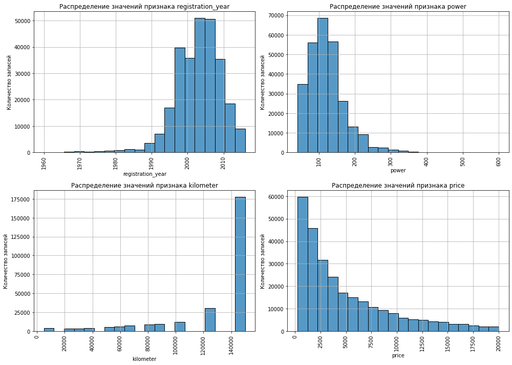

```python
data_research(data)
```

Предобработка данных проведена успешно, всего было удалено 23.08% записей. В результате предобработки мы:

- привели наименования столбцов к змеиному регистру,
- исправили 2 неявных дубликата в уникальных значениях столбцов `'brand'` и `'model'`,
- удалили неинформативные признаки `'date_created'`, `'date_crawled'`, `'last_seen'`, `'registration_month'`, `'number_of_pictures'` и `'postal_code'`,
- заполнили пропуски в столбце `'repaired'` значением `'unknown'`,
- заполнили пропуски в столбцах `'vehicle_type'`, `'gearbox'` и `'fuel_type'` наиболее часто встречающимися значениями для каждой модели автомобиля,
- удалили аномальные значения из столбца `'price'`,
- заменили аномальные значения на медиану в столбцах `'registration_year'`, и `'power'` для каждой модели автомобиля,
- удалили записи со значением `'sonstige_autos'` в столбце `'brand'`,
- всего удалили 9.69% пропушенных и аномальных записей,
- удалили 13.38% явных дубликатов.

Вернуться к содержанию

## Обучение моделей

### Корреляционный анализ

Перед обучением моделей проверим корреляцию признаков.

```python
display(HTML(f'<br><h3>Матрица корреляции признаков</h3>'))
display(data.phik_matrix(interval_cols=num_col(data))\
        .style.background_gradient('cividis'))
```

Матрица корреляции признаков

|  | brand | model | registration_year | vehicle_type | gearbox | fuel_type | power | kilometer | repaired | price |
| --- | --- | --- | --- | --- | --- | --- | --- | --- | --- | --- |
| brand | 1.000000 | 0.998343 | 0.317450 | 0.599923 | 0.526880 | 0.323485 | 0.515052 | 0.268680 | 0.127917 | 0.322367 |
| model | 0.998343 | 1.000000 | 0.637751 | 0.917685 | 0.640786 | 0.550876 | 0.770134 | 0.441806 | 0.222916 | 0.565858 |
| registration_year | 0.317450 | 0.637751 | 1.000000 | 0.168536 | 0.097191 | 0.241164 | 0.187602 | 0.383728 | 0.198733 | 0.646000 |
| vehicle_type | 0.599923 | 0.917685 | 0.168536 | 1.000000 | 0.264567 | 0.320821 | 0.480344 | 0.188737 | 0.092793 | 0.251769 |
| gearbox | 0.526880 | 0.640786 | 0.097191 | 0.264567 | 1.000000 | 0.136073 | 0.556367 | 0.039965 | 0.023574 | 0.297296 |
| fuel_type | 0.323485 | 0.550876 | 0.241164 | 0.320821 | 0.136073 | 1.000000 | 0.218803 | 0.159372 | 0.054178 | 0.235699 |
| power | 0.515052 | 0.770134 | 0.187602 | 0.480344 | 0.556367 | 0.218803 | 1.000000 | 0.131525 | 0.099739 | 0.477195 |
| kilometer | 0.268680 | 0.441806 | 0.383728 | 0.188737 | 0.039965 | 0.159372 | 0.131525 | 1.000000 | 0.244345 | 0.303997 |
| repaired | 0.127917 | 0.222916 | 0.198733 | 0.092793 | 0.023574 | 0.054178 | 0.099739 | 0.244345 | 1.000000 | 0.338123 |
| price | 0.322367 | 0.565858 | 0.646000 | 0.251769 | 0.297296 | 0.235699 | 0.477195 | 0.303997 | 0.338123 | 1.000000 |

Можно заметить, что корреляция между брендом и моделью автомобиля практически равна 1. Это закономерно, ведь модели напрямую связаны с брендами и создают мультиколлинеарность. Но, чтобы избавиться от нее, мы объединим эти два признака в один.

```python
data['model'] = data['brand'] + ' ' + data['model']
data = data.drop('brand', axis=1)
```

Проверяем результат.

```python
data.head()
```

|  | model | registration_year | vehicle_type | gearbox | fuel_type | power | kilometer | repaired | price |
| --- | --- | --- | --- | --- | --- | --- | --- | --- | --- |
| 0 | volkswagen golf | 1993 | sedan | manual | petrol | 101 | 150000 | unknown | 480 |
| 1 | audi other | 2011 | coupe | manual | gasoline | 190 | 125000 | yes | 18300 |
| 2 | jeep grand | 2004 | suv | auto | gasoline | 163 | 125000 | unknown | 9800 |
| 3 | volkswagen golf | 2001 | small | manual | petrol | 75 | 150000 | no | 1500 |
| 4 | skoda fabia | 2008 | small | manual | gasoline | 69 | 90000 | no | 3600 |

Объединение прошло корректно. Теперь изучим матрицу корреляции еще раз.

```python
display(HTML(f'<br><h3>Матрица корреляции признаков</h3>'))
display(data.phik_matrix(interval_cols=num_col(data))\
        .style.background_gradient('cividis'))
```

Матрица корреляции признаков

|  | model | registration_year | vehicle_type | gearbox | fuel_type | power | kilometer | repaired | price |
| --- | --- | --- | --- | --- | --- | --- | --- | --- | --- |
| model | 1.000000 | 0.669400 | 0.923679 | 0.668361 | 0.577793 | 0.780578 | 0.451828 | 0.233529 | 0.573280 |
| registration_year | 0.669400 | 1.000000 | 0.168536 | 0.097191 | 0.241164 | 0.187602 | 0.383728 | 0.198733 | 0.646000 |
| vehicle_type | 0.923679 | 0.168536 | 1.000000 | 0.264567 | 0.320821 | 0.480344 | 0.188737 | 0.092793 | 0.251769 |
| gearbox | 0.668361 | 0.097191 | 0.264567 | 1.000000 | 0.136073 | 0.556367 | 0.039965 | 0.023574 | 0.297296 |
| fuel_type | 0.577793 | 0.241164 | 0.320821 | 0.136073 | 1.000000 | 0.218803 | 0.159372 | 0.054178 | 0.235699 |
| power | 0.780578 | 0.187602 | 0.480344 | 0.556367 | 0.218803 | 1.000000 | 0.131525 | 0.099739 | 0.477195 |
| kilometer | 0.451828 | 0.383728 | 0.188737 | 0.039965 | 0.159372 | 0.131525 | 1.000000 | 0.244345 | 0.303997 |
| repaired | 0.233529 | 0.198733 | 0.092793 | 0.023574 | 0.054178 | 0.099739 | 0.244345 | 1.000000 | 0.338123 |
| price | 0.573280 | 0.646000 | 0.251769 | 0.297296 | 0.235699 | 0.477195 | 0.303997 | 0.338123 | 1.000000 |

Все оставшиеся признаки имеют корреляцию со стоимостью автомобиля, от слабой до заметной.

Наибольшей корреляцией с целевым признаком обладают модель, год ее выпуска, а также мощность автомобиля.

### Подготовка данных

Обучим разные модели:

- LinearRegression,
- RandomForestRegressor,
- LGBMRegressor,
- CatBoostRegressor.

Для каждой модели попробуем подобрать разные гиперпараметры. Но перед этим подготовим данные для обучения моделей.

Делим признаки на входные и целевой.

```python
X = data.drop('price', axis=1)
y = data['price']
```

Разделяем категориальные и количественные признаки.

```python
cat_columns = cat_col(X)
num_columns = num_col(X)
```

Перед разбивкой готовим входные признаки, закодированные при помощи `'LabelEncoder'`.

```python
X_le = X.copy()
le = LabelEncoder()
for col in cat_columns:
    X_le[col] = le.fit_transform(X_le[col])
```

Также отдельно готовим признаки для линейной регрессии, отмасштабированные с помощью `StandardScaler` и закодированные с помощью `OneHotEncoder`.

```python
preprocessor = ColumnTransformer(
    transformers=[
        ('num', StandardScaler(), num_columns),
        ('cat', OneHotEncoder(
            drop='first',
            handle_unknown='ignore',
            sparse_output=False),
         cat_columns)
    ], remainder='passthrough')

X_ohe = preprocessor.fit_transform(X)
```

Разбиваем признаки на тренировочные, валидационные и тестовые выборки.

```python
X_train_le, X_temp_le, y_train_le, y_temp_le = train_test_split(
    X_le,
    y,
    test_size=0.3,
    random_state=RANDOM_STATE
)

X_val_le, X_test_le, y_val_le, y_test_le = train_test_split(
    X_temp_le,
    y_temp_le,
    test_size=0.5,
    random_state=RANDOM_STATE
)
```

```python
X_train_ohe, X_temp_ohe, y_train_ohe, y_temp_ohe = train_test_split(
    X_ohe,
    y,
    test_size=0.3,
    random_state=RANDOM_STATE
)

X_val_ohe, X_test_ohe, y_val_ohe, y_test_ohe = train_test_split(
    X_temp_ohe,
    y_temp_ohe,
    test_size=0.5,
    random_state=RANDOM_STATE
)
```

Проверим размерность получившихся выборок.

```python
for sample_name in ['X_train_le', 'X_val_le', 'X_test_le']:
    sample = eval(sample_name)
    print(f'Доля {sample_name}: {sample.shape[0]/data.shape[0]:.0%}, '
          f'количество столбцов: {sample.shape[1]}')

print('\n')

for sample_name in ['y_train_le', 'y_val_le', 'y_test_le']:
    sample = eval(sample_name)
    print(f'Доля {sample_name}: {sample.shape[0]/data.shape[0]:.0%}')
```

```
Доля X_train_le: 70%, количество столбцов: 8
Доля X_val_le: 15%, количество столбцов: 8
Доля X_test_le: 15%, количество столбцов: 8


Доля y_train_le: 70%
Доля y_val_le: 15%
Доля y_test_le: 15%
```

```python
for sample_name in ['X_train_ohe', 'X_val_ohe', 'X_test_ohe']:
    sample = eval(sample_name)
    print(f'Доля {sample_name}: {sample.shape[0]/data.shape[0]:.0%}, '
          f'количество столбцов: {sample.shape[1]}')

print('\n')

for sample_name in ['y_train_ohe', 'y_val_ohe', 'y_test_ohe']:
    sample = eval(sample_name)
    print(f'Доля {sample_name}: {sample.shape[0]/data.shape[0]:.0%}')
```

```
Доля X_train_ohe: 70%, количество столбцов: 310
Доля X_val_ohe: 15%, количество столбцов: 310
Доля X_test_ohe: 15%, количество столбцов: 310


Доля y_train_ohe: 70%
Доля y_val_ohe: 15%
Доля y_test_ohe: 15%
```

Доли записей распределены корректно. После `OneHotEncoder` количество столбцов в выборках значительно увеличилось, что логично - каждое уникальное значение из категориальных признаков преобразовалось в отдельный столбец.

Создаем таблицу, в которой мы будем сохранять результаты моделей.

```python
results = pd.DataFrame(columns=['Model',
                                'Training Time',
                                'Prediction Time',
                                'Validation RMSE'])
```

### Модель LinearRegression

Создаем пайплайн с моделью LinearRegression.

```python
lr_model = LinearRegression()
```

При помощи функции `model_results` обучаем модель, предсказываем результаты, сохраняем обученную модель и выводим на экран ее метрики.

```python
lr_model, results = model_results(lr_model,
                                  'LinearRegression',
                                  X_train_ohe,
                                  y_train_ohe,
                                  X_val_ohe,
                                  y_val_ohe,
                                  results)

display(results.tail(1))
```

|  | Model | Training Time | Prediction Time | Validation RMSE |
| --- | --- | --- | --- | --- |
| 0 | LinearRegression | 17.844592 | 0.103309 | 2624.65767 |

### Модель RandomForestRegressor

```python
rf_model = RandomForestRegressor(
    n_estimators=50,
    max_depth=10,
    min_samples_split=10,
    min_samples_leaf=4,
    random_state=RANDOM_STATE)
```

```python
rf_model, results = model_results(rf_model,
                                  'RandomForest',
                                  X_train_le,
                                  y_train_le,
                                  X_val_le,
                                  y_val_le,
                                  results)

display(results.tail(1))
```

|  | Model | Training Time | Prediction Time | Validation RMSE |
| --- | --- | --- | --- | --- |
| 1 | RandomForest | 11.632113 | 0.175823 | 1909.466384 |

### Модель LGBMRegressor

```python
lgb_model = lgb.LGBMRegressor(
    n_estimators=100,
    learning_rate=0.1,
    max_depth=10,
    random_state=RANDOM_STATE
)
```

```python
lgb_model, results = model_results(lgb_model,
                                   'LightGBM',
                                   X_train_le,
                                   y_train_le,
                                   X_val_le,
                                   y_val_le,
                                   results)

display(results.tail(1))
```

|  | Model | Training Time | Prediction Time | Validation RMSE |
| --- | --- | --- | --- | --- |
| 2 | LightGBM | 3.934188 | 0.398806 | 1724.425026 |

### Модель CatBoostRegressor

```python
cat_model = CatBoostRegressor(
    iterations=500,
    learning_rate=0.1,
    leaf_estimation_iterations=1,
    random_strength=0.1,
    depth=10,
    random_state=RANDOM_STATE,
    verbose=0
)
```

```python
cat_model, results = model_results(cat_model,
                                   'CatBoost',
                                   X_train_le,
                                   y_train_le,
                                   X_val_le,
                                   y_val_le,
                                   results)

display(results.tail(1))
```

|  | Model | Training Time | Prediction Time | Validation RMSE |
| --- | --- | --- | --- | --- |
| 3 | CatBoost | 26.451286 | 0.087896 | 1621.414216 |

## Анализ моделей

Сравним результаты всех моделей.

```python
display(results)
```

|  | Model | Training Time | Prediction Time | Validation RMSE |
| --- | --- | --- | --- | --- |
| 0 | LinearRegression | 17.844592 | 0.103309 | 2624.657670 |
| 1 | RandomForest | 11.632113 | 0.175823 | 1909.466384 |
| 2 | LightGBM | 3.934188 | 0.398806 | 1724.425026 |
| 3 | CatBoost | 26.451286 | 0.087896 | 1621.414216 |

Уровень точности модели LinearRegression не соответствует требованиям заказчика.

Самое длительное время вычисления предсказаний показала модель LightGBM, поэтому она не подходит.

Оценим работу лучшей модели на тестовой выборке.

```python
test_predictions = cat_model.predict(X_test_le)
test_rmse = round(np.sqrt(
    mean_squared_error(
        y_test_le,
        test_predictions
    )), 2)

print(f'RMSE лучшей модели на тестовой выборке: {test_rmse}')
```

```
RMSE лучшей модели на тестовой выборке: 1662.99
```

На тестовой выборке модель также хорошо показала себя, как и на валидационной.

Заказчику рекомендуется использовать CatBoost для расчета рыночной стоимости автомобиля.

## Общий вывод

**Описание задачи**

В данной проектной работе мы помогли сервису по продаже автомобилей с пробегом «Не бит, не крашен» построить модель, которая поможет клиентам определить рыночную стоимость своего автомобиля. В процессе работы необходимо было учесть критерии, которые важны заказчику: качество предсказания, время обучения и время предсказания модели.

**Этапы работы**

*Предобработка данных:*

В результате предобработки было удалено 23.08% записей. В процессе мы:

- Удалили неинформативные признаки.
- Исправили неявные дубликаты и удалили явные (13.38%).
- Удалили 9.69% пропусков и аномальных значений, остальную часть мы заполнили модой и медианой по каждой модели автомобиля.

*Обучение моделей:*

Заказчику рекомендуется использовать CatBoost для расчета рыночной стоимости автомобиля.

Вернуться к содержанию